# Research Guide

## Logical

#### is_501c3

is_501c3

DATA TYPEboolean

MAX NCHAR5

**PREVIEW**:

```
TRUE · FALSE
```

**PROPERTIES**:

| STAT | VAL | PER |
| --- | --- | --- |
| Rows | 300 |  |
| Distinct | 2 | (0.7%) |

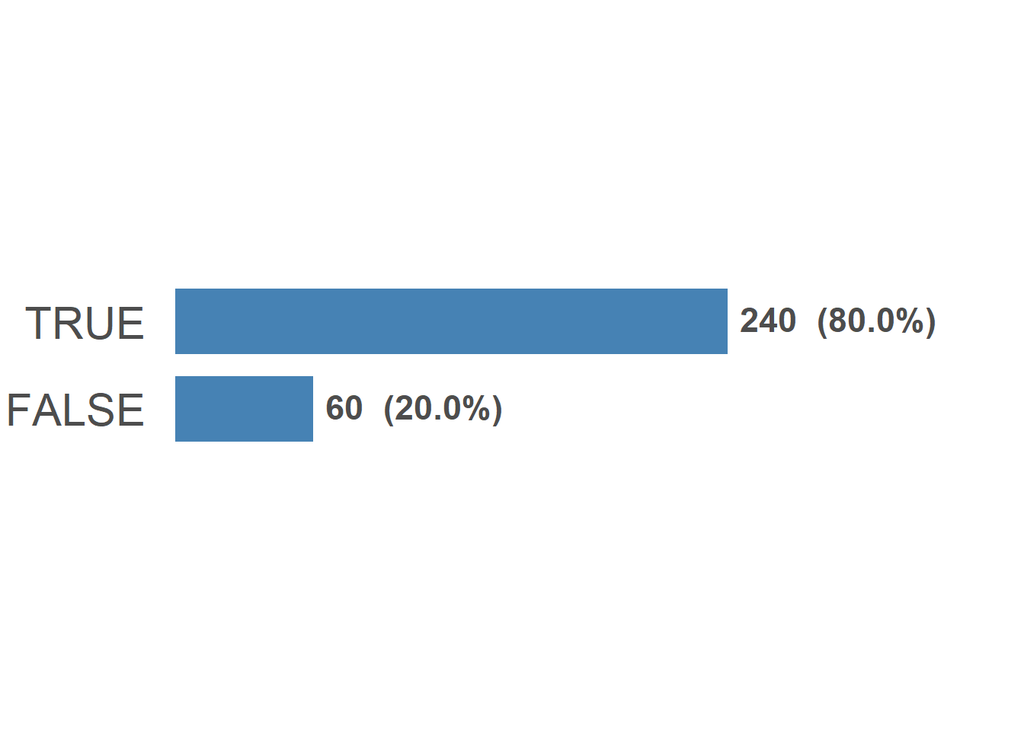

**CATEGORY LABELS**:

| FALSE | TRUE |
| --- | --- |

## Factor

#### ntee_program

ntee_program

DATA TYPEcategorical

MAX NCHAR14

**PREVIEW**:

```
Environment · Health · Human Services · Arts · Education
```

**PROPERTIES**:

| STAT | VAL | PER |
| --- | --- | --- |
| Rows | 300 |  |
| Distinct | 5 | (1.7%) |

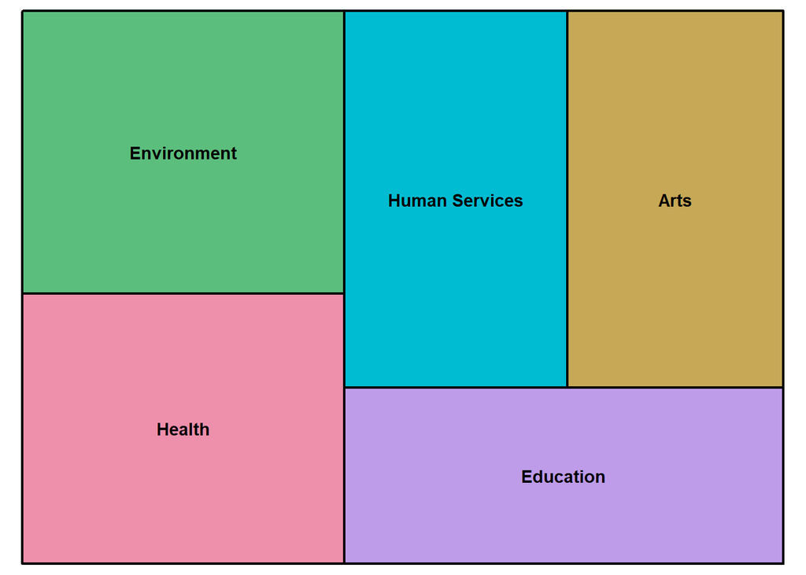

**FACTOR LEVELS**:

| Frequency | (%) | Label |
| --- | --- | --- |
| 65 | (21.7%) | Environment |
| 62 | (20.7%) | Health |
| 60 | (20.0%) | Human Services |
| 58 | (19.3%) | Arts |
| 55 | (18.3%) | Education |

#### num_programs

num_programs

DATA TYPEcategorical

MAX NCHAR 2

**PREVIEW**:

```
5 · 7 · 8 · 4 · 6 · 10 · 9 · 3 · 2 · 1 · 12 · 11 · 13
```

**PROPERTIES**:

| STAT | VAL | PER |
| --- | --- | --- |
| Rows | 300 |  |
| Distinct | 13 | (4.3%) |

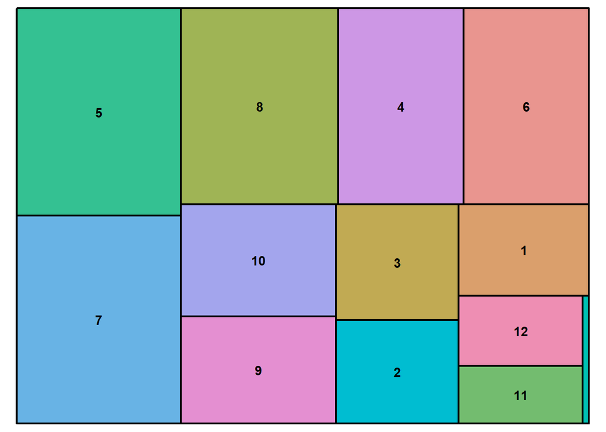

**FACTOR LEVELS**:

| Frequency | (%) | Label |
| --- | --- | --- |
| 43 | (14.3%) | 5 |
| 43 | (14.3%) | 7 |
| 39 | (13.0%) | 8 |
| 31 | (10.3%) | 4 |
| 31 | (10.3%) | 6 |
| 22 | (7.3%) | 10 |
| 21 | (7.0%) | 9 |
| 18 | (6.0%) | 3 |
| 16 | (5.3%) | 2 |
| 15 | (5.0%) | 1 |
| 11 | (3.7%) | 12 |
| 9 | (3.0%) | 11 |
| 1 | (0.3%) | 13 |

## Character

#### org_name

org_name

DATA TYPEtext

MAX NCHAR18

**PREVIEW**:

```
Organization A 158 · Organization A 202 · Organization A 276
Organization A 279 · Organization A 412 · Organization A 530
Organization A 589 · Organization A 604 · Organization A 605
Organization A 657 · Organization A 735 · Organization A 74
```

**PROPERTIES**:

| STAT | VAL | PER |
| --- | --- | --- |
| Rows | 300 |  |
| Distinct | 300 | (100.0%) |

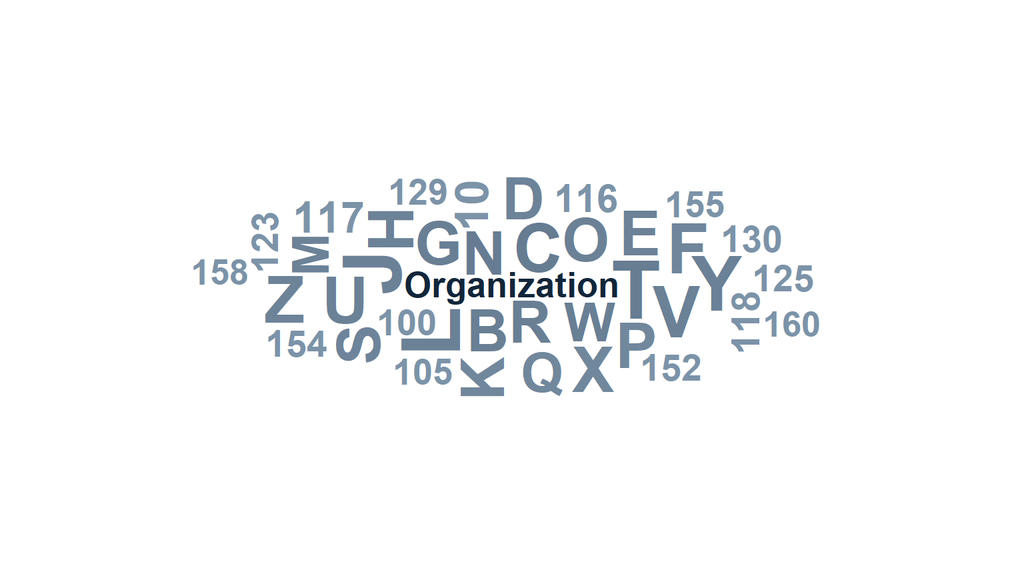

**MOST COMMON VALUES**:

| Value | Frequency | (%) |
| --- | --- | --- |
| Organization A 158 | 1 | (0.3%) |
| Organization A 202 | 1 | (0.3%) |
| Organization A 276 | 1 | (0.3%) |
| Organization A 279 | 1 | (0.3%) |
| Organization A 412 | 1 | (0.3%) |
| Organization A 530 | 1 | (0.3%) |

## Identifier

#### ein

ein

DATA TYPEidentifier

SUBTYPEnumeric_id

CLASSadministrative_id

FORMATplain

MAX NCHAR9

**PREVIEW**:

```
101578358 · 105981903 · 106643114 · 107326985 · 108277070
113137014 · 113200319 · 116652886 · 118561463 · 122903686
123933062 · 130282978 · 132536339 · 133339764 · 146739486
151775857 · 155493354 · 155704899 · 155760701 · 160743970
```

**PROPERTIES**:

| STAT | VAL | PER |
| --- | --- | --- |
| Rows | 300 |  |
| Distinct | 300 | (100.0%) |

**MOST COMMON VALUES**:

| Value | Frequency | (%) |
| --- | --- | --- |
| 101578358 | 1 | (0.3%) |
| 105981903 | 1 | (0.3%) |
| 106643114 | 1 | (0.3%) |
| 107326985 | 1 | (0.3%) |
| 108277070 | 1 | (0.3%) |
| 113137014 | 1 | (0.3%) |

## Temporal

#### day_of_week

day_of_week

DATA TYPEtemporal

UNITdow

MAX NCHAR 3

**PREVIEW**:

```
TUE · WED · MON · THU · FRI · SAT · SUN
```

**PROPERTIES**:

| STAT | VAL | PER |
| --- | --- | --- |
| Rows | 300 |  |
| Distinct | 7 | (2.3%) |

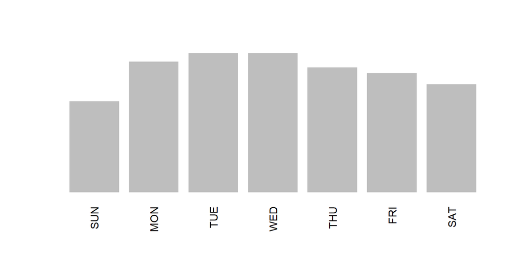

#### date_mdy

date_mdy

DATA TYPEtemporal

UNITdate

MAX NCHAR10

**PREVIEW**:

```
01-01-2017 · 01-24-2015 · 02-18-2015 · 02-24-2018 · 05-17-2017
05-22-2018 · 06-05-2018 · 06-09-2016 · 06-30-2017 · 07-10-2017
07-14-2016 · 08-01-2018 · 08-02-2017 · 08-08-2017 · 08-08-2018
08-26-2017 · 08-27-2016 · 09-10-2017 · 09-11-2017 · 09-19-2015
```

**PROPERTIES**:

| STAT | VAL | PER |
| --- | --- | --- |
| Rows | 300 |  |
| Distinct | 274 | (91.3%) |

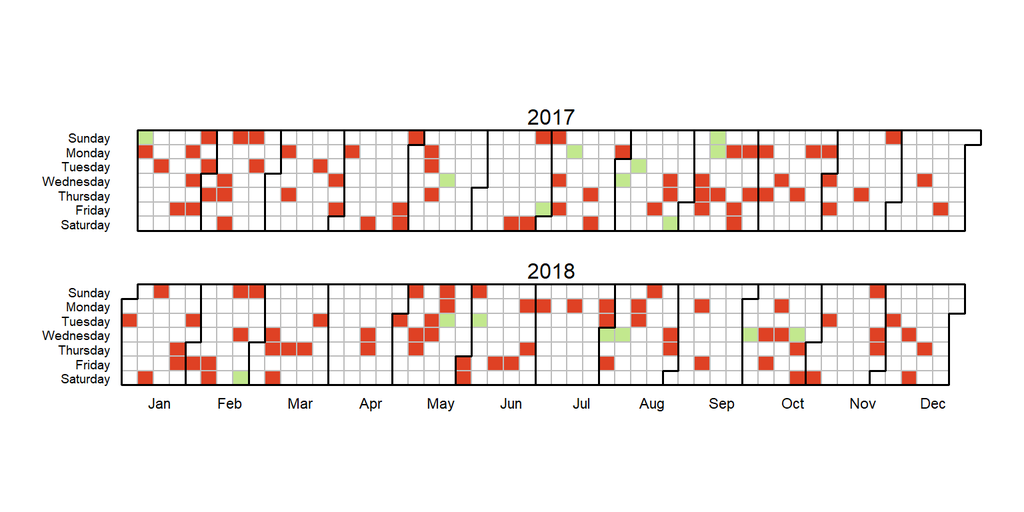

#### date_dmy

date_dmy

DATA TYPEtemporal

UNITdate

MAX NCHAR 8

**PREVIEW**:

```
01-01-17 · 01-08-18 · 02-08-17 · 03-10-18 · 05-06-18 · 06-12-16
08-08-17 · 08-08-18 · 09-06-16 · 10-07-17 · 10-09-17 · 11-09-17
14-07-16 · 17-05-17 · 18-02-15 · 19-09-15 · 20-12-16 · 22-05-18
24-01-15 · 24-02-18 · 24-10-18 · 25-09-15 · 26-08-17 · 26-10-15
```

**PROPERTIES**:

| STAT | VAL | PER |
| --- | --- | --- |
| Rows | 300 |  |
| Distinct | 274 | (91.3%) |

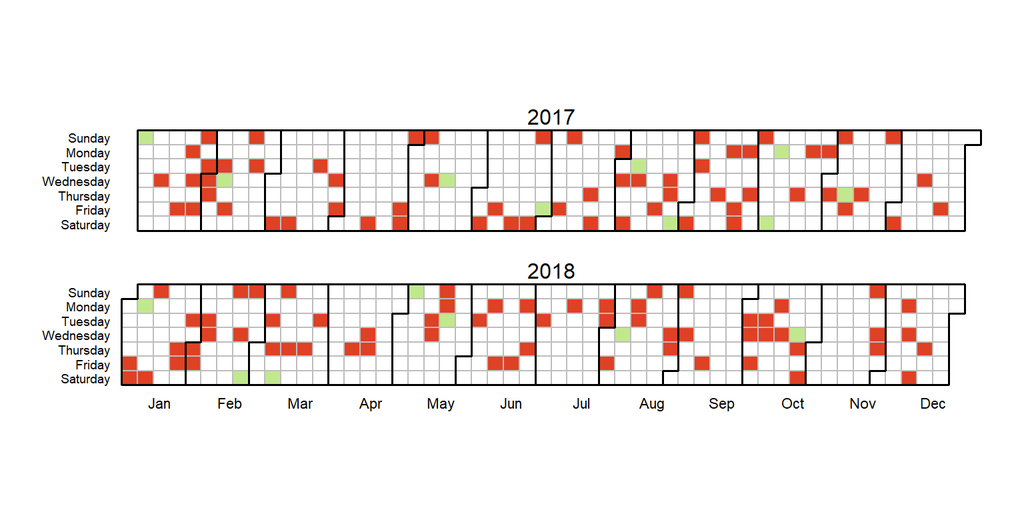

#### month_abbr

month_abbr

DATA TYPEtemporal

UNITmonth

MAX NCHAR 3

**PREVIEW**:

```
SEP · JUN · OCT · AUG · FEB · JAN · JUL · MAR · MAY · APR · NOV
DEC
```

**PROPERTIES**:

| STAT | VAL | PER |
| --- | --- | --- |
| Rows | 300 |  |
| Distinct | 12 | (4.0%) |

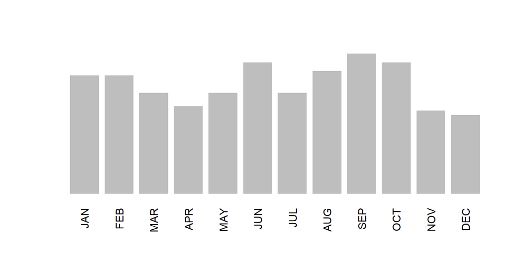

#### month_ym

month_ym

DATA TYPEtemporal

UNITmonth

MAX NCHAR 7

**PREVIEW**:

```
2017-09 · 2017-01 · 2018-05 · 2018-08 · 2018-10 · 2015-06 · 2015-10
2016-09 · 2016-12 · 2017-08 · 2018-06 · 2015-02 · 2015-09 · 2017-07
2018-02 · 2015-03 · 2015-07 · 2016-04 · 2016-06 · 2017-02 · 2015-04
2016-01 · 2016-08 · 2017-10 · 2018-01 · 2018-03 · 2015-01 · 2015-11
```

**PROPERTIES**:

| STAT | VAL | PER |
| --- | --- | --- |
| Rows | 300 |  |
| Distinct | 48 | (16.0%) |

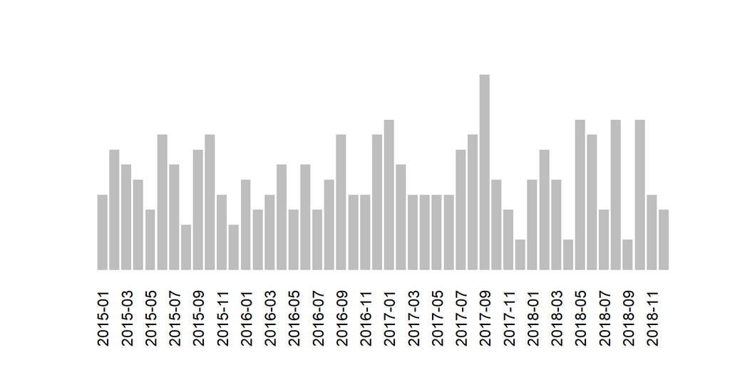

#### hour_ampm

hour_ampm

DATA TYPEtemporal

SUBTYPEpoint

CLASStime_of_day

FORMAThhii

UNIThour

MAX NCHAR 7

**PREVIEW**:

```
1:27pm · 1:51am · 10:26am · 10:27pm · 10:48pm · 12:36am · 2:16am
2:26pm · 2:32am · 2:38am · 2:48pm · 2:55am · 3:02pm · 3:12pm
3:26pm · 3:36pm · 3:42pm · 4:09am · 4:18am · 4:52am · 5:07am
5:18pm · 5:59am · 7:05pm · 7:06am · 7:39am · 8:08am · 8:15am
```

**PROPERTIES**:

| STAT | VAL | PER |
| --- | --- | --- |
| Rows | 300 |  |
| Distinct | 268 | (89.3%) |

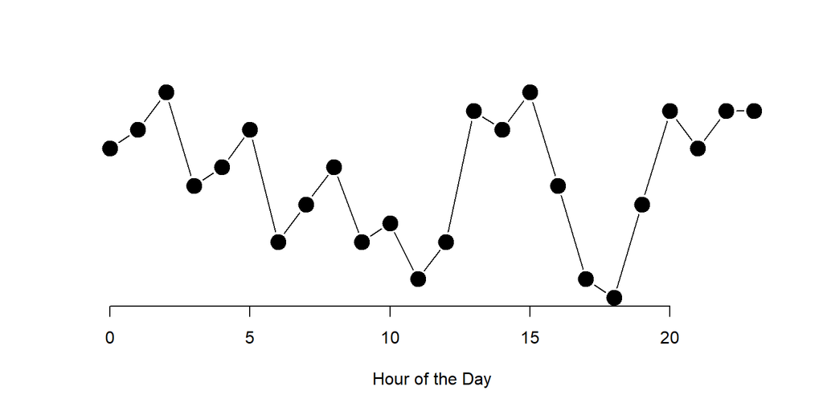

#### event_ts

event_ts

DATA TYPEtemporal

UNITweek

MAX NCHAR23

**PREVIEW**:

```
2015-01-02 11:02:24 MST · 2015-01-16 17:17:50 MST
2015-01-24 01:18:30 MST · 2015-01-24 10:05:07 MST
2015-01-25 14:20:16 MST · 2015-02-02 14:48:47 MST
2015-02-06 01:48:49 MST · 2015-02-09 15:18:51 MST
```

**PROPERTIES**:

| STAT | VAL | PER |
| --- | --- | --- |
| Rows | 300 |  |
| Distinct | 300 | (100.0%) |

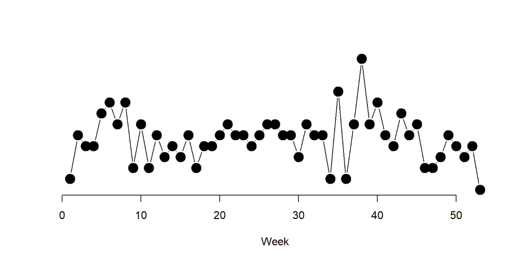

#### rule_year

rule_year

DATA TYPEtemporal

UNITyear

MAX NCHAR 4

**PREVIEW**:

```
1999 · 1964 · 2000 · 1977 · 1992 · 1996 · 2005 · 1957 · 1974 · 1993
1997 · 1998 · 2012 · 1979 · 1987 · 2015 · 1960 · 1962 · 1963 · 1965
1970 · 1972 · 1973 · 1976 · 1981 · 1982 · 1985 · 1988 · 2009 · 2010
2011 · 2014 · 1958 · 1969 · 1975 · 1980 · 1983 · 1984 · 1986 · 1995
```

**PROPERTIES**:

| STAT | VAL | PER |
| --- | --- | --- |
| Rows | 300 |  |
| Distinct | 61 | (20.3%) |

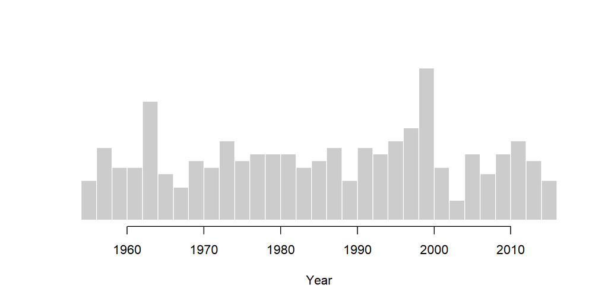

#### age_years

age_years

DATA TYPEtemporal

UNITyear

MAX NCHAR 2

**PREVIEW**:

```
27 · 62 · 26 · 21 · 30 · 34 · 49 · 14 · 28 · 29 · 33 · 52 · 69 · 11
39 · 47 · 12 · 15 · 16 · 17 · 38 · 41 · 44 · 45 · 50 · 53 · 54 · 56
61 · 63 · 64 · 66 · 13 · 19 · 24 · 25 · 31 · 40 · 42 · 43 · 46 · 51
57 · 68 · 18 · 32 · 35 · 36 · 37 · 55 · 59 · 65 · 67 · 70 · 71 · 20
```

**PROPERTIES**:

| STAT | VAL | PER |
| --- | --- | --- |
| Rows | 300 |  |
| Distinct | 61 | (20.3%) |

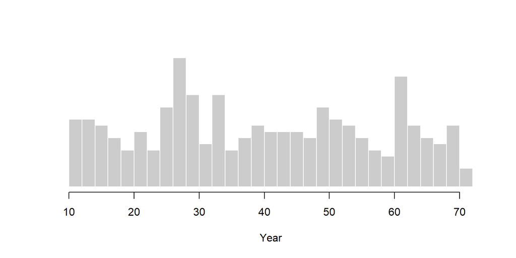